# Beth Whitmore-Stolar CV

2023-01-26

114 Clarton St Syracuse, NY 13212 315-317-8738

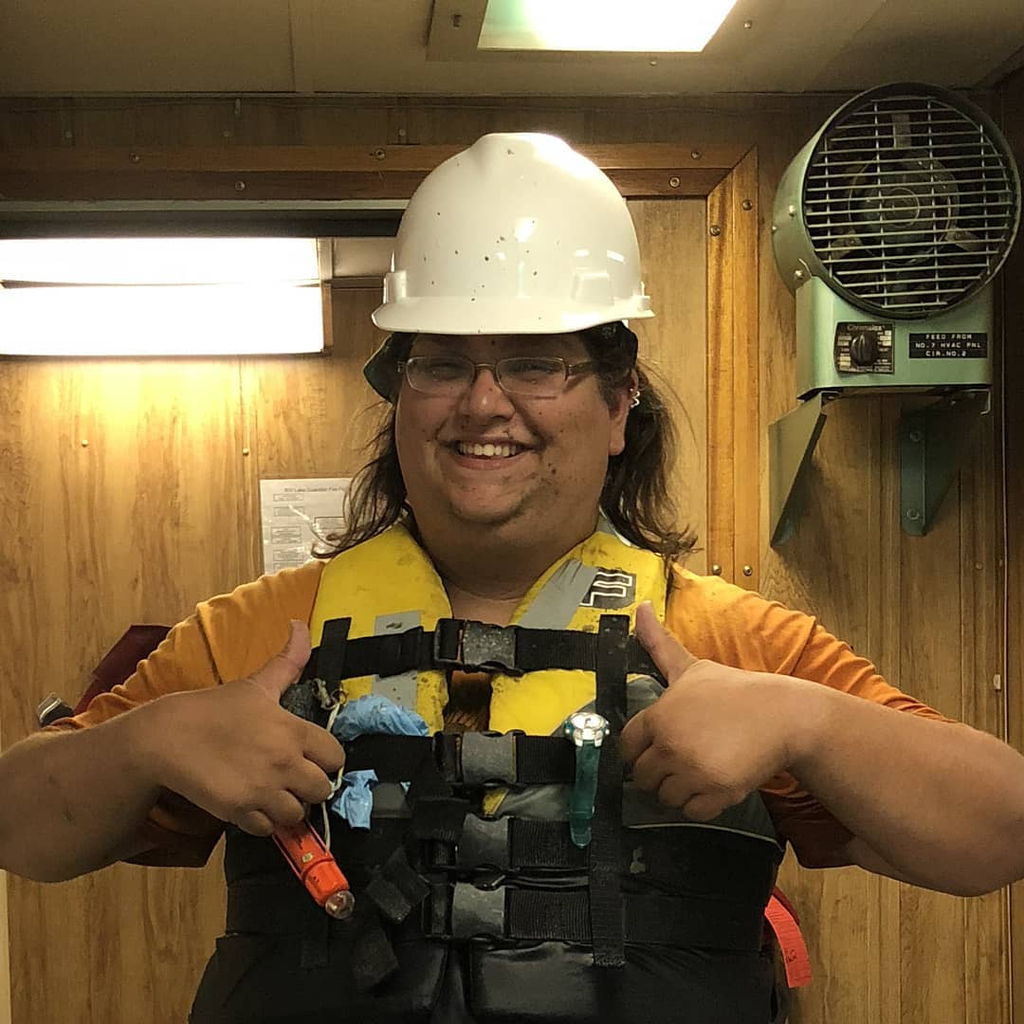

## Education

Bachelor of Science- Zoology 2006 SUNY Oswego  
Associates in Science- Ecology and Environmental Science 2003 Finger Lakes Community Collage

## Work History

2015-Present: Research Technician II at Cornell Biological Field Station at Shackelton Point  
2014-2015: Science Tutor at Finger Lakes Community College  
2013-2014: Lab Technician at Jackson Labs, Bar Harbor, ME

### Experience

- Collecting pelagic and benthic samples via shoreline , canoe, small water craft , and large water craft  
-Analyzing zooplankton samples via microscopy  
-Calibrating water chemistry equipment (YSI, flow cytometer, temperature sensors)  
-Preservation of zooplankton for archiving or genetics work.  
-Advanced zooplankton taxonomy training  
-Experienced in supervising undergraduate students and interns

#### Publications and Presentations

Publications

Whitmore, E. A., J. K. Connolly, J. M. Watkins, and L. G. Rudstam. 2021. An exploration of Lake Ontario’s offshore benthic cladoceran community. Journal of Great Lakes Research 48(2), 428-433.

Whitmore EA, JK Connolly, K Van Damme, JM Watkins, EK Hinchey, and LG Rudstam (2019). First Record of the Neotropical cladoceran Diaphanosoma fluviatile Hansen, 1899 in the Great Lakes basin. BioInvasions Records 8(3):614-622.

Watkins JM, Whitmore, EA, LG Rudstam. 2019. Annual Silver Lake Report 2018. Report to the Rose Conservatory.

Whitmore, E.A., LG Rudstam, J Watkins. 2018. Annual Silver Lake Report 2017. Report to the Rose Conservatory.

Whitmore, EA. 2010. Biology: The living science laboratory manual-Photosynthesis Plants and Pollution pg 99-104 Contributing author: Kevin Tracewski and Ecology Lab pg129-140.

Whitmore, EA, 2008. Zooplankton community structure and dynamics in lakes of contrasting water clarity in Acadia National Park. Contributing authors: Katherine Webster (University of Maine) and Linda Bacon  
(Maine DEP). Report to Acadia National Park Service.